# Credit Risk Modeling

- Tampilkan Semua Kode
- Sembunyikan Semua Kode
- Lihat Sumber

Probability of Default Using Logistic Regression

Penulis

Hilmiya Fahimah

# Ringkasan Eksekutif

Proyek ini mengembangkan model regresi logistik untuk mengestimasi probabilitas gagal bayar (*Probability of Default*, PD) nasabah kartu kredit berdasarkan 30.000 observasi historis dari Taiwan. Transformasi *Weight of Evidence* (WoE), seleksi prediktor berdasarkan *Information Value* (IV), dan pemeriksaan multikolinearitas dilakukan menggunakan data latih. Estimasi parameter dilakukan dengan implementasi Newton-Raphson dan dibandingkan dengan fungsi `glm()` pada R.

Model akhir menggunakan delapan prediktor dan menghasilkan AUC data uji sebesar **0,7557**, koefisien Gini **0,5114**, dan statistik KS **0,3955**. Rerata PD data uji sebesar 21,99%, mendekati proporsi gagal bayar aktual sebesar 22,12%, meskipun masih terdapat perbedaan kalibrasi pada beberapa kelompok risiko. Hasil ini menunjukkan kemampuan diskriminasi yang cukup baik untuk studi kasus pembelajaran, bukan validasi kelayakan model operasional perbankan.

# 1 Pendahuluan

## 1.1 Latar Belakang

Penyaluran kredit merupakan salah satu kegiatan utama perbankan yang tidak terlepas dari risiko gagal bayar. Berdasarkan data Otoritas Jasa Keuangan (OJK, 2026), rasio *Non-Performing Loan* (NPL) gross perbankan Indonesia pada September 2026 tercatat sebesar 2,07%. Pengukuran, pemantauan, dan pengendalian risiko kredit diperlukan dalam mendukung pengelolaan risiko perbankan (Basel Committee on Banking Supervision, 2025).

Salah satu pendekatan dalam pengukuran risiko kredit adalah estimasi *Probability of Default* (PD) menggunakan regresi logistik. Metode ini menghasilkan probabilitas gagal bayar berdasarkan karakteristik nasabah dan memungkinkan interpretasi parameter model. Regresi logistik masih menjadi pembanding yang kuat dalam penelitian prediksi risiko kredit. Menurut Seitshiro dan Govender (2024) model tersebut unggul pada data registri kredit perbankan komersial, meskipun transformasi WoE tidak meningkatkan kinerjanya pada data tersebut.

Proyek ini menerapkan regresi logistik menggunakan dataset *Default of Credit Card Clients* (Yeh, 2009), melalui transformasi dan seleksi variabel, estimasi parameter dengan metode Newton-Raphson, serta evaluasi performa model. Analisis berfokus pada penerapan statistika dan komputasi matematis sebagai studi kasus risiko kredit.

## 1.2 Tujuan

Proyek ini bertujuan untuk:

1. Mengeksplorasi karakteristik data nasabah kartu kredit dan distribusi status gagal bayar.
2. Menerapkan WoE dan IV dalam transformasi serta seleksi prediktor dan memeriksa multikolinearitas menggunakan *Variance Inflation Factor* (VIF).
3. Mengestimasi parameter regresi logistik menggunakan metode Newton-Raphson dan membandingkan hasilnya dengan `glm()` pada R.
4. Mengevaluasi performa model berdasarkan AUC, koefisien Gini, statistik KS, dan kalibrasi probabilitas gagal bayar.

# 2 Eksplorasi dan Persiapan Data

## 2.1 Deskripsi Dataset

Dataset *Default of Credit Card Clients* diperoleh dari UCI Machine Learning Repository (Yeh, 2009) dengan lisensi CC BY 4.0. Dataset berisi 30.000 observasi nasabah kartu kredit di Taiwan, dengan riwayat pembayaran April–September 2005. Terdapat 25 kolom yang terdiri atas satu identitas, 23 kandidat prediktor awal, dan satu variabel respons. Variabel `default` menyatakan status gagal bayar pada bulan berikutnya: 1 untuk gagal bayar dan 0 untuk tidak gagal bayar.

Deskripsi variabel berdasarkan dokumentasi UCI dan penamaan pada script proyek.

| Variabel | Keterangan |
| --- | --- |
| `ID` | Identitas observasi; bukan prediktor |
| `LIMIT_BAL` | Batas kredit (NT$) |
| `SEX`, `EDUCATION`, `MARRIAGE`, `AGE` | Jenis kelamin, pendidikan, status pernikahan, usia |
| `PAY_0`, `PAY_2`–`PAY_6` | Status pembayaran September hingga April 2005 |
| `BILL_AMT1`–`BILL_AMT6` | Jumlah tagihan bulanan (NT$) |
| `PAY_AMT1`–`PAY_AMT6` | Jumlah pembayaran bulanan (NT$) |
| `default` | Status gagal bayar bulan berikutnya (0/1) |

## 2.2 Eksplorasi Data

Pemeriksaan dataset asli menunjukkan tidak terdapat nilai kosong dan tidak terdapat duplikasi baris lengkap. Seluruh 30.000 identitas observasi bersifat unik. Jika ID diabaikan, terdapat 35 baris dengan kombinasi nilai yang berulang (setelah kemunculan pertama); hal ini tidak membuktikan adanya duplikasi nasabah, sehingga tidak ada baris yang dihapus. Sebanyak 6.636 nasabah (22,12%) mengalami gagal bayar, sedangkan 23.364 nasabah (77,88%) tidak mengalami gagal bayar. Distribusi tersebut menunjukkan ketidakseimbangan kelas, sehingga pembagian data perlu menjaga proporsi masing-masing kelas.

**Lihat Kode R**

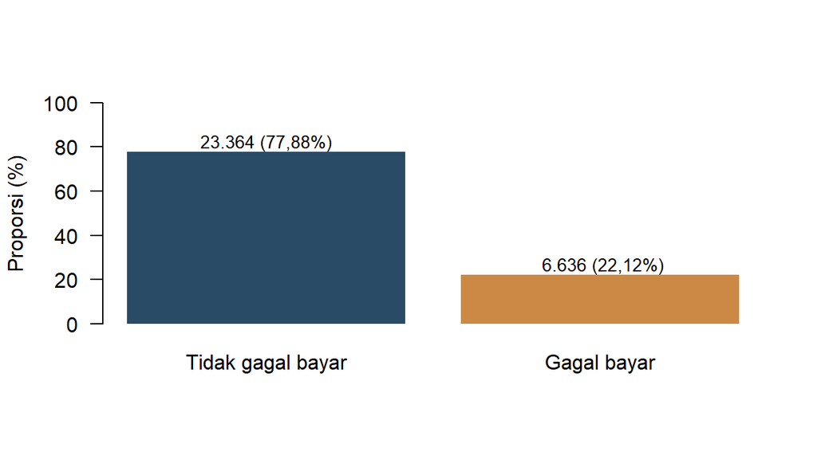

Gambar 1: Distribusi status gagal bayar pada seluruh dataset

```r
n_default <- table(factor(df$default, levels = c(0, 1)))
bp <- barplot(100*prop.table(n_default), names.arg=c("Tidak gagal bayar", "Gagal bayar"), col=c(navy, orange), ylim=c(0, 100), ylab="Proporsi (%)", border=NA, las=1)
text(bp, 100*prop.table(n_default)+4, labels=paste0(format(as.numeric(n_default), big.mark=".", scientific=FALSE), " (", format(round(100*prop.table(n_default),2), decimal.mark=","), "%)"), cex=.85)
```

Statistik deskriptif empat variabel numerik yang dipertimbangkan pada tahap transformasi WoE disajikan berikut. Statistik ini merupakan ringkasan tambahan yang dihitung dari data proyek.

Statistik deskriptif seluruh observasi; variabel keuangan dalam NT$ dan usia dalam tahun.

| Variabel | Rerata | Median | Simpangan baku | Minimum | Maksimum |
| --- | --- | --- | --- | --- | --- |
| `LIMIT_BAL` | 167.484,32 | 140.000 | 129.747,66 | 10.000 | 1.000.000 |
| `AGE` | 35,49 | 34 | 9,22 | 21 | 79 |
| `BILL_AMT1` | 51.223,33 | 22.381,50 | 73.635,86 | -165.580 | 964.511 |
| `PAY_AMT1` | 5.663,58 | 2.100 | 16.563,28 | 0 | 873.552 |

Rerata tagihan dan pembayaran September lebih tinggi daripada mediannya, menunjukkan adanya nilai besar dan kecenderungan distribusi menceng ke kanan. Nilai tagihan negatif tercatat dalam dataset dan dipertahankan pada proyek ini; makna bisnis setiap nilai tersebut tidak diverifikasi lebih lanjut.

Status pembayaran (PAY_) dikodekan −1 untuk pembayaran tepat waktu dan 1 sampai 9 untuk keterlambatan; nilai −2 dan 0 yang muncul pada data tidak didefinisikan dalam dokumentasi UCI. Kolom bernama PAY_0 (September), PAY_2 (Agustus), dan seterusnya mundur sampai PAY_6 (April). Pada data latih, tingkat gagal bayar nilai −2 dan 0 hampir sama (PAY_0: 12,6% dan 12,8%), sedangkan nilai −1 berbeda (16,8% pada PAY_0 dan 15,7%–16,9% pada PAY_3–PAY_6). Karena itu −2 dan 0 digabung dan −1 dipertahankan. Pada seluruh data, nilai 1 hampir tidak muncul pada PAY_2–PAY_6 (28, 4, 2, 0, 0 observasi) padahal ada 3.688 pada PAY_0, sehingga nilai 1 dan 2 digabung pada kolom-kolom tersebut.

## 2.3 Pembersihan dan Transformasi Data

Pembersihan dilakukan dengan mengelompokkan kategori pendidikan dan status pernikahan yang tidak dijelaskan dalam dokumentasi UCI ke kategori lainnya. Kolom `default payment next month` juga diubah namanya menjadi `default`. Tidak dilakukan imputasi atau penghapusan observasi.

Pengelompokan kategori pada script `01_data.R`.

| Variabel | Kode awal | Jumlah observasi yang diubah | Kode hasil |
| --- | --- | --- | --- |
| `EDUCATION` | 0, 5, 6 | 345 | 4 (lainnya) |
| `MARRIAGE` | 0 | 54 | 3 (lainnya) |

Pengelompokan tersebut merupakan keputusan prapemrosesan dan tidak menyatakan bahwa arti setiap kode awal telah diketahui. Transformasi WoE dibahas secara terpisah pada bagian metodologi.

## 2.4 Pembagian Data Latih dan Data Uji

Dataset dibagi menjadi data latih (*train*) dan data uji (*test*) dengan proporsi 70:30 melalui pengambilan sampel terstratifikasi berdasarkan variabel `default`. Pengaturan `set.seed(123)` digunakan untuk mendukung reproduksibilitas pada lingkungan R yang sama. Data latih digunakan untuk menentukan batas pengelompokan, pemetaan WoE, seleksi prediktor, dan estimasi parameter. Data uji menggunakan pemetaan yang telah dibentuk pada data latih.

Hasil pembagian data secara terstratifikasi.

| Dataset | Tidak gagal bayar | Gagal bayar | Total | Proporsi gagal bayar |
| --- | --- | --- | --- | --- |
| Data latih | 16.355 | 4.645 | 21.000 | 22,12% |
| Data uji | 7.009 | 1.991 | 9.000 | 22,12% |
| Total | 23.364 | 6.636 | 30.000 | 22,12% |

Proporsi kedua kelas tetap hampir sama pada data latih dan uji. Tidak terdapat nilai kosong pada hasil transformasi WoE kedua dataset. Pemisahan proses pembentukan transformasi dari evaluasi mengurangi risiko kebocoran informasi dari data uji.

# 3 Metodologi Analisis

## 3.1 Weight of Evidence (WoE)

WoE merupakan transformasi yang mengukur perbandingan distribusi nasabah tidak gagal bayar (*good*) dan gagal bayar (*bad*) pada setiap kelompok prediktor. Pendekatan ini digunakan dalam pemodelan risiko kredit untuk mengubah informasi kategori menjadi nilai numerik (Seitshiro & Govender, 2024).

Pada proyek ini, 11 dari 23 kandidat prediktor awal dipertimbangkan: `LIMIT_BAL`, `AGE`, `EDUCATION`, enam variabel `PAY`, `BILL_AMT1`, dan `PAY_AMT1`. Empat variabel numerik dikelompokkan menggunakan kuantil data latih (maksimal lima kelompok); `EDUCATION` menggunakan kategori yang telah dibersihkan. Untuk riwayat pembayaran, kode −2 dan 0 digabungkan, kode −1 dipertahankan, dan keterlambatan tiga bulan atau lebih digabungkan. Pada `PAY_0`, kode 1 dan 2 dipisahkan, sedangkan pada lima variabel pembayaran sebelumnya kedua kode tersebut digabungkan (alasan pengelompokan dijelaskan pada Bagian 2.2). `SEX` dan `MARRIAGE` tidak dimasukkan sebagai kandidat karena penggunaan jenis kelamin dan status pernikahan dalam keputusan kredit dapat bersifat diskriminatif. `BILL_AMT2`–`BILL_AMT6` dan `PAY_AMT2`–`PAY_AMT6` tidak dianalisis agar cakupan tetap terbatas; hanya `BILL_AMT1` dan `PAY_AMT1` yang dipertimbangkan.

Misalkan $G_j$ dan $B_j$ menyatakan jumlah nasabah tidak gagal bayar dan gagal bayar pada kelompok ke-$j$, serta $m$ adalah jumlah kelompok yang terisi. Proyek ini menggunakan koreksi 0,5 pada setiap kelompok untuk menghindari pembagian dengan nol:

$$g_j=\frac{G_j+0{,}5}{\sum_{h=1}^{m}G_h+0{,}5m},\qquad
b_j=\frac{B_j+0{,}5}{\sum_{h=1}^{m}B_h+0{,}5m}.$$

$$\operatorname{WoE}_j=\ln\left(\frac{g_j}{b_j}\right).
\tag{1}$$

WoE positif menunjukkan kelompok yang relatif lebih banyak direpresentasikan oleh nasabah tidak gagal bayar, sedangkan WoE negatif menunjukkan kelompok yang relatif lebih banyak direpresentasikan oleh nasabah gagal bayar. Batas pengelompokan dan nilai WoE ditetapkan dari data latih, kemudian diterapkan apa adanya pada data uji tanpa dihitung ulang, sehingga tidak ada informasi dari data uji yang masuk ke dalam model.

## 3.2 Information Value (IV)

IV merangkum daya pemisahan suatu prediktor terhadap dua kelas respons berdasarkan distribusi per kelompok. Rumus yang digunakan adalah:

$$IV=\sum_{j=1}^{m}(g_j-b_j)\ln\left(\frac{g_j}{b_j}\right).
\tag{2}$$

Nilai yang lebih besar menunjukkan pemisahan kelas univariat yang lebih kuat dalam data latih. IV tidak mengukur kontribusi independen prediktor setelah variabel lainnya dikendalikan. Secara matematis, IV dengan distribusi positif tersebut sama dengan jumlah dua divergensi Kullback–Leibler (divergensi Jeffreys):

$$\begin{aligned}
D_{KL}(g\Vert b)+D_{KL}(b\Vert g)
&=\sum_j g_j\ln\frac{g_j}{b_j}+\sum_j b_j\ln\frac{b_j}{g_j}\\
&=\sum_j(g_j-b_j)\ln\frac{g_j}{b_j}=IV.
\end{aligned}$$

Kesetaraan ini juga diperiksa untuk `PAY_0` pada script `03_woe_iv.R`.

## 3.3 Seleksi Variabel dan Uji Multikolinearitas

Seleksi dilakukan dengan meninjau IV serta memeriksa korelasi dan multikolinearitas prediktor yang telah ditransformasi menjadi WoE. VIF mengukur peningkatan varians estimasi koefisien yang berkaitan dengan hubungan linear antarprediktor:

$$VIF_j=\frac{1}{1-R_j^2},$$

dengan $R_j^2$ adalah koefisien determinasi dari regresi prediktor ke-$j$ terhadap prediktor lainnya. Pada proyek ini, VIF diperoleh dari diagonal invers matriks korelasi dan nilai 5 digunakan sebagai ambang pemeriksaan. Ambang tersebut merupakan aturan praktis, bukan uji hipotesis formal.

Sembilan prediktor ditetapkan sebagai kandidat regresi berdasarkan hasil eksplorasi IV; `AGE` dan `BILL_AMT1` tidak dimasukkan karena nilai IV relatif kecil. Script tidak menerapkan ambang IV otomatis. Model dengan dan tanpa `PAY_2` kemudian dibandingkan melalui AIC, BIC, dan uji rasio likelihood. Model akhir mengikuti pilihan pada script `06_newton_raphson.R`, yaitu model tanpa `PAY_2`.

## 3.4 Regresi Logistik

Variabel respons $Y_i$ mengikuti model Bernoulli dengan probabilitas gagal bayar $p_i$. Untuk vektor prediktor WoE $\mathbf{x}_i$ yang memuat intersep dan vektor parameter $\boldsymbol\beta$, digunakan model:

$$\eta_i=\mathbf{x}_i^T\boldsymbol\beta,\qquad
p_i=P(Y_i=1\mid \mathbf{x}_i)=\frac{e^{\eta_i}}{1+e^{\eta_i}}.
\tag{3}$$

Transformasi logit menghubungkan probabilitas dengan kombinasi linear prediktor:

$$\begin{aligned}
\frac{p_i}{1-p_i}&=e^{\eta_i},\\
\ln\left(\frac{p_i}{1-p_i}\right)&=\eta_i=\mathbf{x}_i^T\boldsymbol\beta.
\end{aligned}$$

Parameter diestimasi melalui *Maximum Likelihood Estimation* (MLE). Dengan asumsi observasi independen bersyarat pada prediktor, fungsi likelihood dan log-likelihood adalah:

$$L(\boldsymbol\beta)=\prod_{i=1}^n p_i^{y_i}(1-p_i)^{1-y_i},$$

$$\begin{aligned}
\ell(\boldsymbol\beta)&=\sum_{i=1}^n[y_i\ln p_i+(1-y_i)\ln(1-p_i)]\\
&=\sum_{i=1}^n[y_i\eta_i-\ln(1+e^{\eta_i})].
\end{aligned}
\tag{4}$$

Maksimisasi log-likelihood regresi logistik umumnya memerlukan metode numerik (Pennsylvania State University, tanpa tahun-b).

## 3.5 Metode Newton-Raphson

Turunan pertama dan kedua log-likelihood terhadap parameter diperoleh menggunakan $\partial p_i/\partial\eta_i=p_i(1-p_i)$:

$$\begin{aligned}
\mathbf{g}(\boldsymbol\beta)&=\nabla\ell(\boldsymbol\beta)=\mathbf{X}^T(\mathbf{y}-\mathbf{p}),\\
\mathbf{H}(\boldsymbol\beta)&=\nabla^2\ell(\boldsymbol\beta)=-\mathbf{X}^T\mathbf{W}\mathbf{X},\\
\mathbf{W}&=\operatorname{diag}\{p_i(1-p_i)\}.
\end{aligned}$$

Dengan pendekatan Taylor pada gradien di sekitar iterasi ke-$t$ dan menetapkan gradien pada solusi mendekati nol, diperoleh:

$$\begin{aligned}
\mathbf{0}&\approx\mathbf{g}(\boldsymbol\beta^{(t)})+\mathbf{H}(\boldsymbol\beta^{(t)})(\boldsymbol\beta^{(t+1)}-\boldsymbol\beta^{(t)}),\\
\boldsymbol\beta^{(t+1)}&=\boldsymbol\beta^{(t)}-\mathbf{H}^{-1}\mathbf{g}\\
&=\boldsymbol\beta^{(t)}+(\mathbf{X}^T\mathbf{W}\mathbf{X})^{-1}\mathbf{X}^T(\mathbf{y}-\mathbf{p}).
\end{aligned}
\tag{5}$$

Implementasi menggunakan parameter awal nol, maksimum 25 iterasi, dan kriteria berhenti berupa perubahan absolut maksimum parameter kurang dari $10^{-10}$. Fungsi `solve()` menyelesaikan sistem linear tanpa menghitung invers secara eksplisit pada langkah iterasi. Hasil dibandingkan dengan `glm()` yang menggunakan *iteratively reweighted least squares* (IRLS) sebagai metode standar (R Core Team, tanpa tahun). Untuk regresi logistik dengan link logit, langkah Newton-Raphson dan IRLS ekuivalen secara aljabar.

# 4 Hasil Pemodelan

## 4.1 Hasil Transformasi WoE dan IV

| Variabel | Jumlah kelompok | IV | Kandidat regresi awal |
| --- | --- | --- | --- |
| `PAY_0` | 5 | 0,8983 | Ya |
| `PAY_2` | 4 | 0,5575 | Ya |
| `PAY_3` | 4 | 0,4269 | Ya |
| `PAY_4` | 4 | 0,3727 | Ya |
| `PAY_5` | 4 | 0,3511 | Ya |
| `PAY_6` | 4 | 0,2994 | Ya |
| `LIMIT_BAL` | 5 | 0,1605 | Ya |
| `PAY_AMT1` | 5 | 0,1564 | Ya |
| `EDUCATION` | 4 | 0,0382 | Ya |
| `AGE` | 5 | 0,0149 | Tidak |
| `BILL_AMT1` | 5 | 0,0092 | Tidak |

**Lihat Kode R**

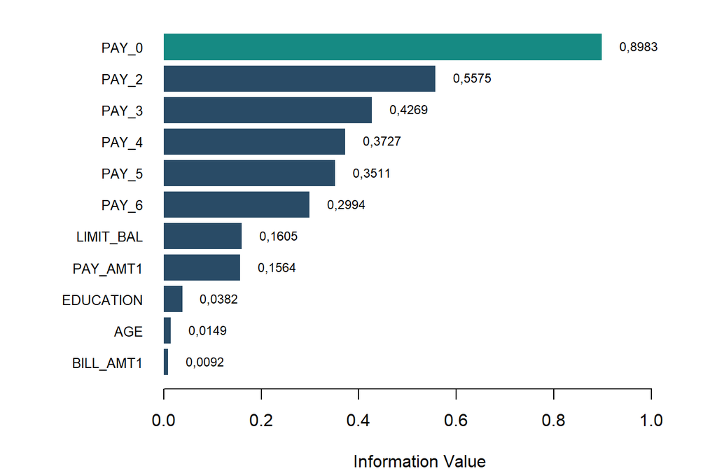

Gambar 2: Information Value dari 11 kandidat prediktor pada data latih

```r
iv <- sapply(tabel_woe, function(t) {
  g <- (t$good+.5)/sum(t$good+.5)
  b <- (t$bad+.5)/sum(t$bad+.5)
  sum((g-b)*log(g/b))
})
iv <- sort(iv)
old <- par(mar=c(4, 8, 1, 2))
bp <- barplot(iv, horiz=TRUE, las=1, col=ifelse(names(iv)=="PAY_0", teal, navy), border=NA, xlim=c(0,1.05), xlab="Information Value", cex.names=.8)
text(iv+.015, bp, format(round(iv,4), decimal.mark=","), pos=4, cex=.75)
par(old)
```

`PAY_0` (status pembayaran September) memiliki IV tertinggi, yaitu 0,8983, diikuti `PAY_2`. Riwayat pembayaran merupakan kelompok informasi yang paling kuat dalam membedakan kedua kelas pada analisis univariat. IV `AGE` dan `BILL_AMT1` relatif kecil dibandingkan kandidat lain.

Hasil pengelompokan WoE `PAY_0` pada data train.

| Kelompok `PAY_0` | Jumlah | Tidak gagal bayar | Gagal bayar | Default rate | WoE |
| --- | --- | --- | --- | --- | --- |
| -2/0 | 12.229 | 10.670 | 1.559 | 12,75% | 0,6648 |
| -1 | 3.994 | 3.325 | 669 | 16,75% | 0,3445 |
| 1 | 2.563 | 1.697 | 866 | 33,79% | -0,5859 |
| 2 | 1.887 | 575 | 1.312 | 69,53% | -2,0828 |
| ≥3 | 327 | 88 | 239 | 73,09% | -2,2539 |

**Lihat Kode R**

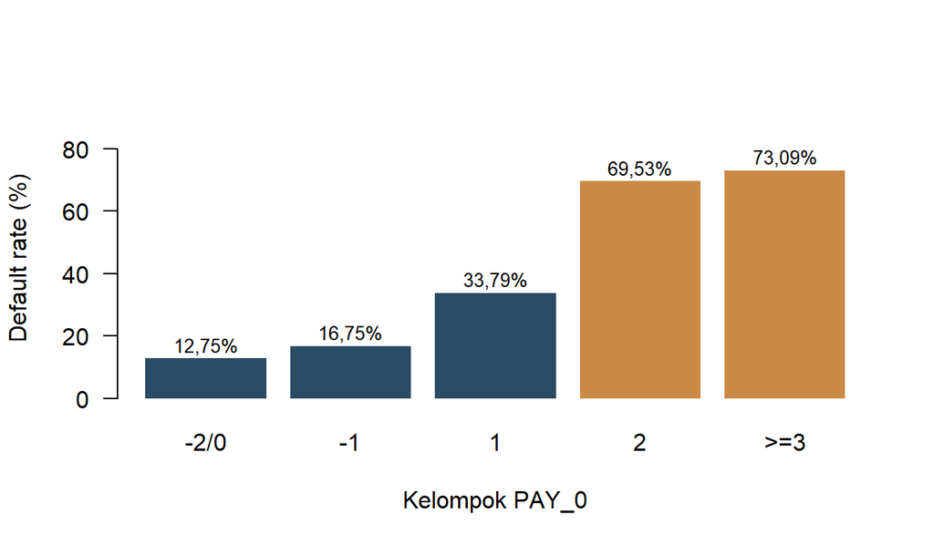

Gambar 3: Proporsi gagal bayar aktual menurut kelompok status pembayaran bulan September

```r
t0 <- tabel_woe$PAY_0
rate <- 100*t0$bad/(t0$good+t0$bad)
bp <- barplot(rate, names.arg=t0$kelompok, ylim=c(0,90), col=ifelse(rate>50,orange,navy), border=NA, ylab="Default rate (%)", xlab="Kelompok PAY_0", las=1)
text(bp,rate+4,paste0(format(round(rate,2),decimal.mark=","),"%"),cex=.8)
```

Peningkatan keterlambatan pada September berkaitan dengan kenaikan proporsi gagal bayar bulan berikutnya. Pada kelompok keterlambatan dua bulan, proporsi gagal bayar mencapai 69,53%, jauh lebih tinggi dibandingkan kelompok -2/0 (12,75%). Ini merupakan hubungan empiris, bukan bukti kausal.

## 4.2 Hasil Seleksi Variabel

Korelasi Spearman antarkolom status pembayaran sebelum transformasi berada pada kisaran 0,47–0,83; nilai tertinggi terdapat pada `PAY_5` dan `PAY_6`. Setelah transformasi WoE, pemeriksaan VIF pada sembilan kandidat menghasilkan nilai berikut.

VIF dihitung dari invers matriks korelasi WoE pada data latih.

| Variabel | VIF awal | VIF model akhir |
| --- | --- | --- |
| `PAY_0` | 1,86 | 1,44 |
| `PAY_2` | 2,66 | — |
| `PAY_3` | 2,32 | 1,92 |
| `PAY_4` | 2,43 | 2,43 |
| `PAY_5` | 2,61 | 2,60 |
| `PAY_6` | 1,97 | 1,96 |
| `LIMIT_BAL` | 1,15 | 1,15 |
| `PAY_AMT1` | 1,23 | 1,13 |
| `EDUCATION` | 1,05 | 1,05 |

Seluruh VIF awal kurang dari 5, sehingga tidak ada variabel yang dihapus berdasarkan kriteria VIF. Namun, koefisien `PAY_2` pada model penuh bernilai positif (0,0935), berlawanan dengan arah negatif yang diharapkan dari pengkodean WoE good/bad. Karena koefisien multivariat bersifat kondisional, pembalikan arah ini tidak otomatis berarti variabel tersebut keliru atau model gagal.

Perbandingan model berdasarkan data latih; dihitung ulang dari model binomial.

| Model | AIC | BIC | Deviance |
| --- | --- | --- | --- |
| Penuh (9 prediktor) | 18.318,0 | 18.397,5 | 18.298,0 |
| Tanpa `PAY_2` (8 prediktor) | 18.322,2 | 18.393,7 | 18.304,2 |

Uji rasio likelihood untuk model bersarang menghasilkan statistik 6,1887 dengan satu derajat bebas dan p-value 0,0129. Dengan demikian, model penuh lebih didukung oleh AIC dan uji rasio likelihood, sementara BIC lebih mendukung model tanpa `PAY_2`. Model akhir proyek mempertahankan delapan prediktor mengikutikeputusan pada tahap pemodelan; pilihan ini dapat dipahami sebagai kompromi antara kesederhanaan dan konsistensi arah koefisien, tetapi tidak dapat dinyatakan sebagai model yang secara statistik unggul berdasarkan semua kriteria. Karena keputusan tersebut dilakukan setelah peninjauan data latih, p-value digunakan sebagai informasi eksploratif.

## 4.3 Estimasi Parameter

Estimasi Newton-Raphson dilakukan pada matriks desain berukuran 21.000 × 9, termasuk intersep. Riwayat iterasi Newton-Raphson disajikan berikut.

Riwayat iterasi Newton-Raphson.

| Iterasi | Log-likelihood sebelum pembaruan | Maksimum perubahan parameter |
| --- | --- | --- |
| 1 | -14.556,0908 | 0,9563215 |
| 2 | -9.372,3502 | 0,2447340 |
| 3 | -9.156,8726 | 0,0528126 |
| 4 | -9.152,0801 | 0,0027055 |
| 5 | -9.152,0755 | 0,000004685 |
| 6 | -9.152,0755 | sekitar $1,00\times10^{-11}$ |

Pada iterasi keenam, perubahan parameter sudah memenuhi kriteria konvergensi. Log-likelihood akhir sebesar -9.152,0755. Nilai eigen minimum matriks informasi pada solusi sekitar 98,8989, menunjukkan matriks informasi positif definit pada solusi yang diperiksa.

## 4.4 Perbandingan Hasil Estimasi

Tabel berikut membandingkan koefisien asli Newton-Raphson dengan hasil perhitungan ulang model binomial-logit menggunakan `glm()`. Keduanya mengestimasi model dan parameter yang sama.

**Lihat Kode R**

```r
fit_glm <- glm(reformulate(pilih_final,response="default"),data=woe_train,family=binomial())
X <- cbind(1,as.matrix(woe_train[,pilih_final]))
p <- as.vector(plogis(X%*%beta_nr))
info <- crossprod(X,X*(p*(1-p)))
se <- sqrt(diag(solve(info)))
knitr::kable(data.frame(Variabel=names(beta_nr),Newton_Raphson=as.numeric(beta_nr),GLM=as.numeric(coef(fit_glm)),SE_NR=se),digits=4,col.names=c("Variabel","Newton-Raphson","glm()","SE Newton-Raphson"),row.names=FALSE, format.args=list(decimal.mark=","))
```

Tabel 1: Perbandingan koefisien Newton-Raphson dan glm serta standard error

| Variabel | Newton-Raphson | glm() | SE Newton-Raphson |
| --- | --- | --- | --- |
| (Intercept) | -1,2429 | -1,2429 | 0,0188 |
| PAY_0 | -0,7573 | -0,7573 | 0,0212 |
| PAY_3 | -0,2544 | -0,2544 | 0,0378 |
| PAY_4 | -0,1273 | -0,1273 | 0,0467 |
| PAY_5 | -0,1670 | -0,1670 | 0,0495 |
| PAY_6 | -0,1909 | -0,1909 | 0,0470 |
| LIMIT_BAL | -0,4128 | -0,4128 | 0,0496 |
| PAY_AMT1 | -0,4556 | -0,4556 | 0,0489 |
| EDUCATION | -0,3909 | -0,3909 | 0,0999 |

Hasil Newton-Raphson yang tersimpan juga diperiksa secara independen melalui model binomial-logit berbasis IRLS. Koefisien pada kedua pendekatan sama hingga empat desimal, dan log-likelihood akhir yang diperoleh konsisten. Ini menunjukkan implementasi numerik menghasilkan solusi yang sesuai untuk model yang sama, bukan bahwa model pasti akurat pada populasi lain.

## 4.5 Interpretasi Model

Seluruh koefisien prediktor pada model akhir bernilai negatif. Karena WoE menggunakan rasio good terhadap bad, peningkatan WoE berkaitan dengan penurunan log-odds gagal bayar setelah prediktor lain dikendalikan. Sebagai contoh, koefisien `PAY_0` sebesar -0,7573 menghasilkan *odds ratio* $e^{-0{,}7573}\approx0{,}469$ untuk kenaikan satu unit WoE. Artinya, odds gagal bayar menjadi sekitar 46,9% dari odds sebelumnya, dengan prediktor lain tetap. Perubahan ini berlaku pada skala WoE, bukan kenaikan satu bulan keterlambatan atau penurunan probabilitas sebesar 53,1 poin persentase.

# 5 Evaluasi Model

## 5.1 ROC Curve dan AUC

Kurva ROC membandingkan *true positive rate* (TPR) dengan *false positive rate* (FPR) pada berbagai ambang prediksi. AUC dapat diinterpretasikan sebagai peluang model memberikan skor lebih tinggi kepada nasabah gagal bayar daripada nasabah tidak gagal bayar yang dipilih secara acak, dengan setengah bobot untuk skor yang sama. Pada script proyek, AUC dihitung menggunakan peringkat skor dan diperiksa menggunakan perbandingan pasangan (lihat juga dokumentasi scikit-learn developers, tanpa tahun).

$$AUC=\frac{\sum_{i:y_i=1}R_i-n_1(n_1+1)/2}{n_1n_0},$$

dengan $R_i$ adalah peringkat skor (peringkat rata-rata untuk nilai yang sama), serta $n_1$ dan $n_0$ masing-masing jumlah observasi gagal bayar dan tidak gagal bayar.

Metrik evaluasi pada data latih dan data uji.

| Dataset | AUC | Gini | KS |
| --- | --- | --- | --- |
| Data latih | 0,7699 | 0,5398 | 0,4167 |
| Data uji | 0,7557 | 0,5114 | 0,3955 |

**Lihat Kode R**

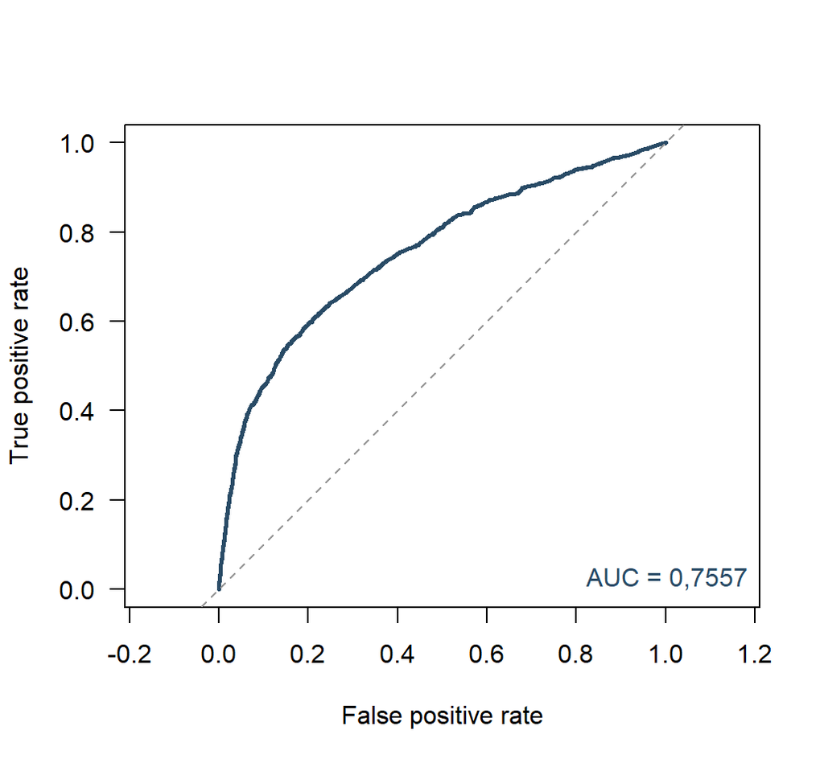

Gambar 4: Kurva ROC pada data uji (skor yang sama dikelompokkan)

```r
ord <- order(pd_test,decreasing=TRUE)
last <- c(which(diff(pd_test[ord])!=0),length(ord))
tpr <- c(0,cumsum(y_test[ord]==1)[last]/sum(y_test==1))
fpr <- c(0,cumsum(y_test[ord]==0)[last]/sum(y_test==0))
plot(fpr,tpr,type="l",lwd=2.5,col=navy,xlab="False positive rate",ylab="True positive rate",xlim=c(0,1),ylim=c(0,1),asp=1,las=1)
abline(0,1,lty=2,col="gray60")
legend("bottomright",legend=paste0("AUC = ",format(hasil$AUC[hasil$data=="test"],decimal.mark=",")),bty="n",text.col=navy)
```

AUC data uji sebesar 0,7557 berarti peluang pemeringkatan pasangan nasabah yang benar sekitar 75,57% (dengan perlakuan skor sama sebagaimana dijelaskan di atas). AUC bukan persentase klasifikasi yang benar pada suatu ambang tertentu. Selisih AUC data latih dan data uji sebesar 0,0142, menunjukkan penurunan diskriminasi yang relatif kecil pada pembagian data ini.

## 5.2 Koefisien Gini

Koefisien Gini diskriminasi dihitung dari AUC:

$$Gini=2\,AUC-1.$$

Gini data uji sebesar 0,5114 menunjukkan daya pemisahan yang lebih baik daripada pemeringkatan acak (Gini = 0). Metrik ini merupakan transformasi AUC, bukan bukti evaluasi independen.

## 5.3 Statistik Kolmogorov-Smirnov (KS)

KS mengukur selisih absolut maksimum antara fungsi distribusi kumulatif empiris skor nasabah tidak gagal bayar dan gagal bayar:

$$KS=\sup_s |F_0(s)-F_1(s)|.$$

Nilai KS data uji sebesar 0,3955 berarti jarak maksimum antara kedua distribusi kumulatif mencapai 39,55 poin persentase. Nilai tersebut menunjukkan adanya pemisahan distribusi skor, tetapi tidak menyatakan bahwa tingkat akurasi model sebesar 39,55%.

## 5.4 Kalibrasi Model

Kalibrasi menilai kesesuaian probabilitas yang diprediksi dengan proporsi kejadian aktual (scikit-learn developers, tanpa tahun-a). Data uji dibagi menjadi sepuluh kelompok berdasarkan kuantil PD. Jumlah observasi per kelompok tidak selalu sama karena terdapat skor PD identik.

**Lihat Kode R**

```r
knitr::kable(data.frame(Kelompok=tab_kal$kelompok,n=tab_kal$n,Prediksi=paste0(format(100*tab_kal$rerata_prediksi,nsmall=2,decimal.mark=","),"%"),Aktual=paste0(format(100*tab_kal$rerata_aktual,nsmall=2,decimal.mark=","),"%")),col.names=c("Kelompok","Jumlah","Rerata PD","Default aktual"),row.names=FALSE)
```

Tabel 2: Kalibrasi PD pada data uji

| Kelompok | Jumlah | Rerata PD | Default aktual |
| --- | --- | --- | --- |
| 1 | 904 | 8,05% | 7,74% |
| 2 | 898 | 9,60% | 8,91% |
| 3 | 1029 | 10,98% | 9,04% |
| 4 | 831 | 12,25% | 10,95% |
| 5 | 863 | 13,59% | 16,34% |
| 6 | 876 | 15,07% | 15,87% |
| 7 | 899 | 16,74% | 18,69% |
| 8 | 900 | 23,28% | 27,33% |
| 9 | 900 | 39,28% | 38,78% |
| 10 | 900 | 71,38% | 68,22% |

**Lihat Kode R**

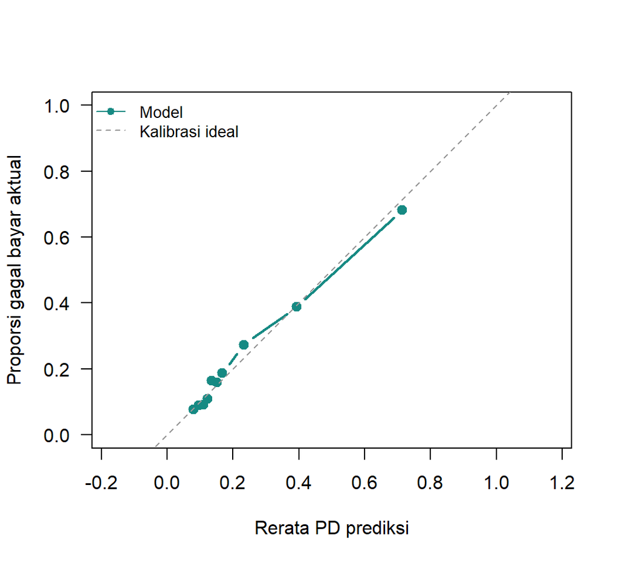

Gambar 5: Perbandingan rata-rata probabilitas prediksi dan proporsi gagal bayar aktual

```r
plot(tab_kal$rerata_prediksi,tab_kal$rerata_aktual,type="b",pch=19,col=teal,lwd=2,xlim=c(0,1),ylim=c(0,1),xlab="Rerata PD prediksi",ylab="Proporsi gagal bayar aktual",asp=1,las=1)
abline(0,1,lty=2,col="gray60")
legend("topleft",legend=c("Model","Kalibrasi ideal"),col=c(teal,"gray60"),lty=c(1,2),pch=c(19,NA),bty="n",cex=.85)
```

Rerata PD data uji sebesar 21,99%, sementara proporsi gagal bayar aktual sebesar 22,12%. Selisih sekitar 0,13 poin persentase menunjukkan kesesuaian agregat yang dekat. Namun, kalibrasi kelompok tidak sempurna. Kelompok ke-8 memiliki rerata PD 23,28% dan gagal bayar aktual 27,33%, sehingga model meremehkan risiko sekitar 4,05 poin persentase. Pada kelompok ke-10, PD prediksi 71,38% melebihi kejadian aktual 68,22% sekitar 3,16 poin persentase. Oleh karena itu, kesesuaian agregat tidak cukup untuk menyimpulkan bahwa model terkalibrasi baik di seluruh rentang risiko.